# POL2012: Theories and Models in Political Economy

Marius Swane Wishman

Department of Sociology and Political Science

## The Global Financial Crisis

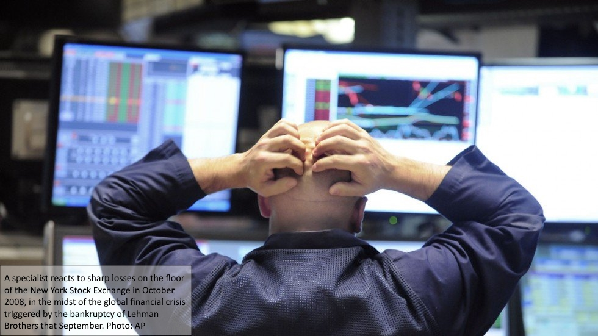

## Real Estate bubble

- Home prices up 60%, 2000-2006
- Subprime loans
- Securitization

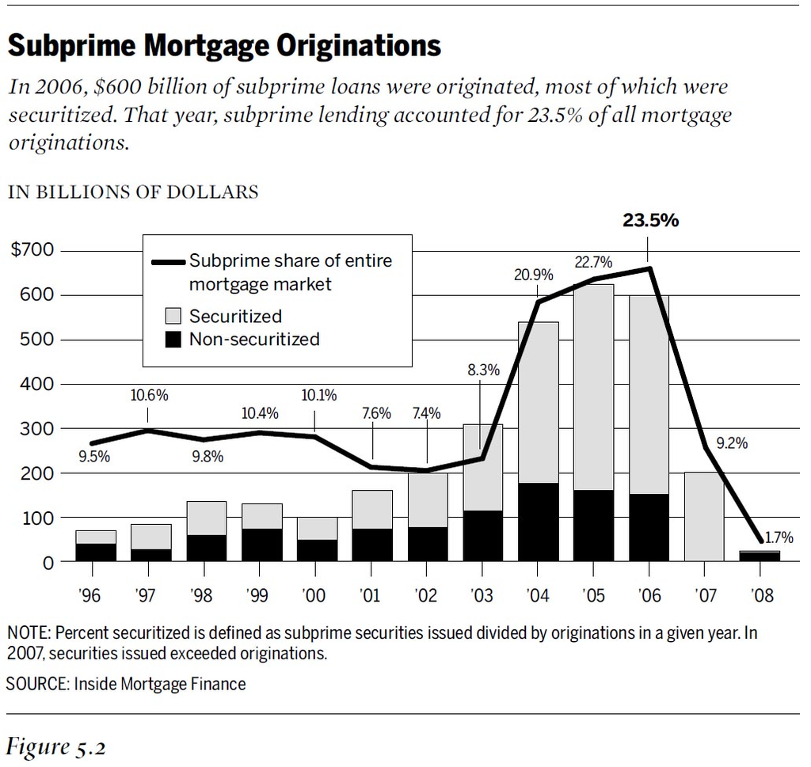

## Not a New Phenomenon

1720s: South Sea Bubble - 1790s: Canal mania - 1840s: Railway mania - 1890: Baring crisis - 1929: Great Depression - 1997-98: Asian financial crisis - 2001: Dot.com bubble

## Why?

- Schumpeterians:

  Financial crises are linked to long economic waves. (Empirically 50-60 years.)
- Marxists:

  Capitalism creates financial crises
- Keynesians:

  Financial crises occur when we don’t regulate capitalism
- Neoclassics:

  Government involement creates artificial markets and inefficiencies

## Asian Financial Crisis

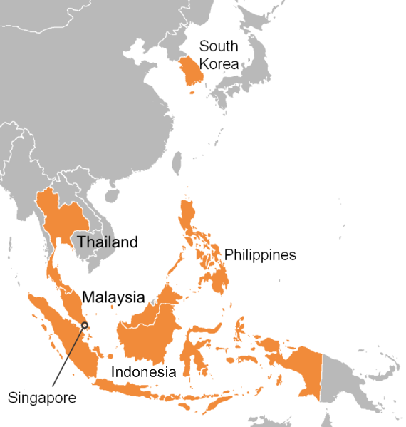

## Asian Financial Crisis; systemic problems

- Banking systems still underdeveloped
- Foreign loans
  - What if there is a devaluation?
- Quasi-contractual relationships between political and economic elites
  - Moral hazard
- Dollar peg
  - Dollar appreciates -> local currencies appreciate

## Asian Financial Crisis; Shit Hits the Fan

- Moral hazard -> Bad Loans
  - Real estate bubble
  - Insolvent banks and financial institutions
- Dollar peg
  - Appreciating dollar -> Overvalued local currencies -> Speculative attacks
- Massive outflows of capital
  - Foreign exchange reserves drained
  - From fixed to float, depreciations

## Response

- $200 billion injected into the market by the Fed, the ECB and the Bank of England
- Expansionary monetary policy -> low interest-rates.
- United States continued stimulus in the range of $800 billion
- ECB turned to fiscal discipline
- Sovreign debt

## The problem of diversity

- What is appropriate for Germany may not be appropriate for certain other EU countries
- And vice-versa
- The United States has this problem too!
- BUT, its easier to get Americans to bail out fellow Americans

## And who did better?

[interactive chart not shown]

[figure not shown]

## Lazy Greeks or Austerity?

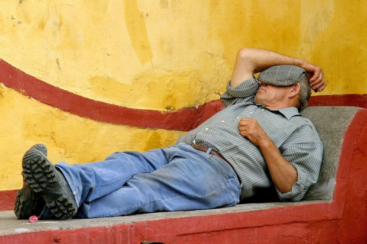

[figure not shown]

## Some perspectives

- Piketty: “Germany has never repaid its debts. It has no right to lecture Greece.”
- Two ways to repay debt:
  - Strict budgetary discipline over 100 years
  - Inflation, tax on private wealth, debt relief
- Krugman: Eliminating deficits during a crisis is a recipe for depression. Leave the Euro.
- Ferguson: Clean slate makes no sense if the problem is structural (see Fukuyama ch6 for account of some of Greece’s structural problems).

## Ferguson has Opinions

[video not shown]

## Do we even need monetary systems?

- Facilitates international transactions
- Makes trade easier and more predictable
- To avoid financial crises.
- Crypto-currency?

## Europe going the way of Japan?

- No growth, no inflation, negative interest rates
- A crisis of production and inovation?